# Simulating parallel universes with ms

Peter Ralph

May 4, 2015

**Scenario:** Parallel “universe” lattices with some migration between “universes” in a zone of “universe” overlap.

A demographic model is a list of population models on the same grid, with a bit more information (time to switch for each). The way to build a demographic model is to:

1. Start with a grid,
2. then moving backwards in time, copy the last state,
3. then modify it.

The function `add_to_demography` does this copy-and-modify step; and demographic models can be modified directly by subsetting.

# Building the demographic model

## Initialization

First, let’s choose the parameters for the grid:

```r
nrow <- 100               # width of grid
ncol <- 40                # height of grid
overlap.size <- 20        # with of the overlap (in the middle)
admix.rate <- 0.05
mig.rate <- 1
```

Now, set up the grid.

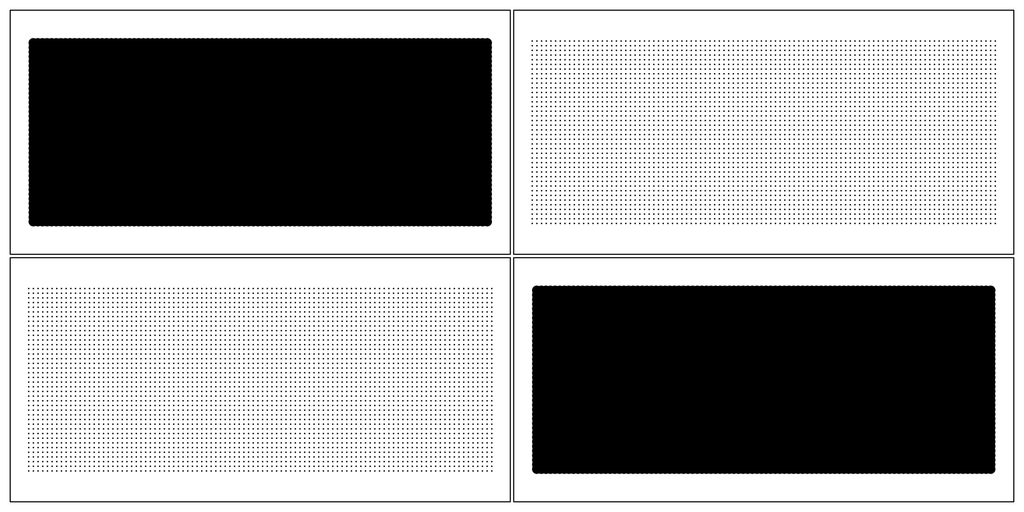

```r
ga <- grid_array(nlayers=2,nrow=nrow,ncol=ncol,N=1,mig.rate=mig.rate,admix.rate=admix.rate)
plot(ga)
```

## Create the overlap

Then, we modify that first state, by zeroing out populations in each layer where we don’t want them. We do this by creating ‘masks’ for each and using `modify_grid_layer`, which multiplies `N` by the mask we pass in with `dN`:

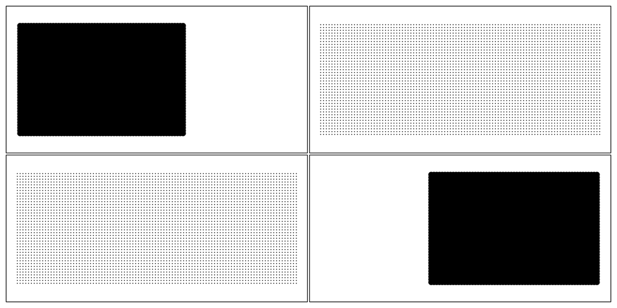

```r
mask.1 <- mask.2 <- matrix(1,nrow=nrow(ga),ncol=ncol(ga))
mask.1[row(mask.1) > nrow(ga)/2+overlap.size/2] <- 0
mask.2[row(mask.1) < nrow(ga)/2-overlap.size/2] <- 0
ga <- modify_grid_layer( ga, layer=1, dN=mask.1 )
ga <- modify_grid_layer( ga, layer=2, dN=mask.2 )
plot(ga)
```

# Simulating with ms

## Trees, in R

```r
sample.config <- sample_locations( ga, n=30, each=2 )
sample.cols <- rainbow(nrow(sample.config))
sample.config
```

```
##       row col layer n
##  [1,]  50   1     1 2
##  [2,]  94   1     1 2
##  [3,]  86   2     1 2
##  [4,]  37   3     1 2
##  [5,]  13   4     1 2
##  [6,]  15   7     1 2
##  [7,]   9  12     1 2
##  [8,]  24  12     1 2
##  [9,]  45  15     1 2
## [10,]  25  21     1 2
## [11,]  55  22     1 2
## [12,]  18  23     1 2
## [13,]  36  25     1 2
## [14,]  99  25     1 2
## [15,]   8  26     1 4
## [16,]  41  26     1 2
## [17,]  40  30     1 2
## [18,]  36  31     1 2
## [19,]  98  38     1 2
## [20,]  26   9     2 2
## [21,]  27  10     2 2
## [22,]  75  11     2 2
## [23,]  17  20     2 2
## [24,]  21  20     2 2
## [25,]  75  21     2 2
## [26,]  20  24     2 2
## [27,]  54  33     2 2
## [28,]  32  34     2 2
## [29,]  49  35     2 2
```

With this in hand, we can run `ms`. We’ll ask it to output trees, not sequence. For some reason, it gives an error if we keep it all in `R`: maybe the string of parameters is too long? (Using `tofile=TRUE` puts the parameters in a file, passed to `ms` via `-f`.)

```r
ms.output <- run_ms( ga, nsamp=sample.config, trees=TRUE, nreps=3 )
```

```
## Outputting to  msarg_159977  .
```

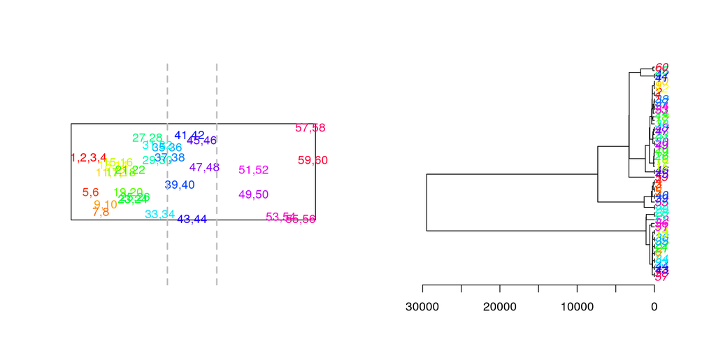

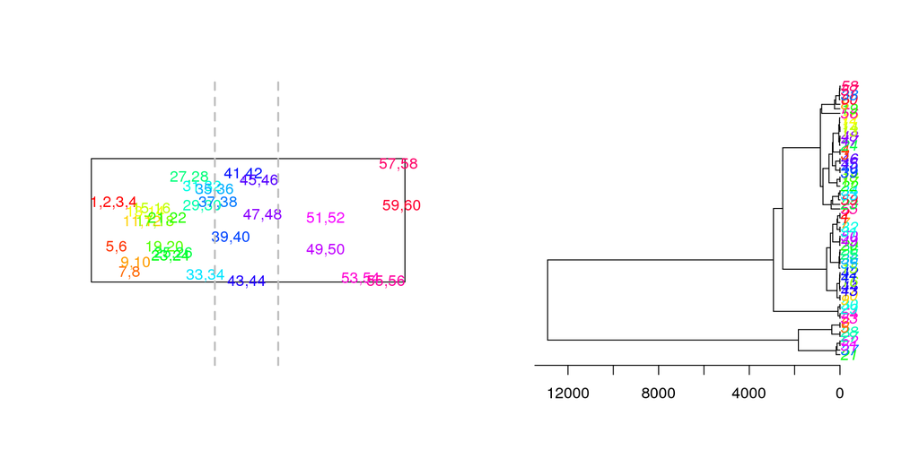

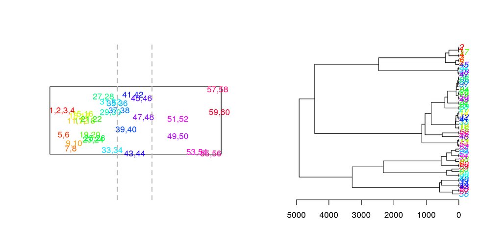

```r
tree.output <- trees_from_ms( file.path(ms.output,"msoutput.txt") )
layout(t(1:2))
for (tree in tree.output) {
    plot_sample_config( ga, sample.config )
    abline(v=(nrow(ga)+c(1,-1)*overlap.size)/2, lty=2, lwd=2, col='grey')
    ape::plot.phylo( tree, tip.color=sample.cols[findInterval(as.numeric(tree$tip.label),1+c(0,cumsum(sample.config[,4])))] )
    ape::axisPhylo(1)
}
```

## Sequence, to a file

To get sequence, we could do as follows, this time outputting to a directory:

```r
ms.output <- run_ms( ga, nsamp=sample.config, theta=0.01 )
```

```
## Outputting to  msarg_549067  .
```

```r
cat(paste(scan(file.path(ms.output,"msoutput.txt"),what='char',sep='\n'),collapse='\n'))
```

[output not shown]

[output cut: 10 more lines]

[output not shown]